# Risk Factor Analysis

## Outcome Variable

**Outcome Variable:** whz

## Predictor Variables

**Intervention Variable:** impfloor

**Adjustment Set:**

- arm
- sex
- W_mage
- meducyrs
- feducyrs
- hhwealth_quart
- hfoodsec
- W_mhtcm
- W_mwtkg
- W_mbmi
- W_nrooms
- W_nchldlt5
- W_parity
- impsan
- safeh20
- delta_W_mage
- delta_meducyrs
- delta_feducyrs
- delta_hhwealth_quart
- delta_hfoodsec
- delta_W_mhtcm
- delta_W_mwtkg
- delta_W_mbmi
- delta_W_nrooms
- delta_W_nchldlt5
- delta_W_parity
- delta_impsan
- delta_safeh20

## Stratifying Variables

The analysis was stratified on these variable(s):

- agecat
- studyid
- country

## Data Summary

| agecat | studyid | country | impfloor | n_cell | n |
| --- | --- | --- | --- | --- | --- |
| Birth | ki0047075b-MAL-ED | BANGLADESH | 1 | 185 | 201 |
| Birth | ki0047075b-MAL-ED | BANGLADESH | 0 | 16 | 201 |
| Birth | ki0047075b-MAL-ED | BRAZIL | 1 | 55 | 57 |
| Birth | ki0047075b-MAL-ED | BRAZIL | 0 | 2 | 57 |
| Birth | ki0047075b-MAL-ED | INDIA | 1 | 33 | 39 |
| Birth | ki0047075b-MAL-ED | INDIA | 0 | 6 | 39 |
| Birth | ki0047075b-MAL-ED | NEPAL | 1 | 8 | 24 |
| Birth | ki0047075b-MAL-ED | NEPAL | 0 | 16 | 24 |
| Birth | ki0047075b-MAL-ED | PERU | 1 | 37 | 210 |
| Birth | ki0047075b-MAL-ED | PERU | 0 | 173 | 210 |
| Birth | ki0047075b-MAL-ED | SOUTH AFRICA | 1 | 86 | 95 |
| Birth | ki0047075b-MAL-ED | SOUTH AFRICA | 0 | 9 | 95 |
| Birth | ki0047075b-MAL-ED | TANZANIA, UNITED REPUBLIC OF | 1 | 5 | 111 |
| Birth | ki0047075b-MAL-ED | TANZANIA, UNITED REPUBLIC OF | 0 | 106 | 111 |
| Birth | ki1000108-CMC-V-BCS-2002 | INDIA | 1 | 68 | 68 |
| Birth | ki1000108-CMC-V-BCS-2002 | INDIA | 0 | 0 | 68 |
| Birth | ki1000108-IRC | INDIA | 1 | 253 | 253 |
| Birth | ki1000108-IRC | INDIA | 0 | 0 | 253 |
| Birth | ki1017093-NIH-Birth | BANGLADESH | 1 | 505 | 572 |
| Birth | ki1017093-NIH-Birth | BANGLADESH | 0 | 67 | 572 |
| Birth | ki1017093b-PROVIDE | BANGLADESH | 1 | 485 | 532 |
| Birth | ki1017093b-PROVIDE | BANGLADESH | 0 | 47 | 532 |
| Birth | ki1017093c-NIH-Crypto | BANGLADESH | 1 | 542 | 707 |
| Birth | ki1017093c-NIH-Crypto | BANGLADESH | 0 | 165 | 707 |
| Birth | ki1113344-GMS-Nepal | NEPAL | 1 | 97 | 503 |
| Birth | ki1113344-GMS-Nepal | NEPAL | 0 | 406 | 503 |
| Birth | ki1114097-CONTENT | PERU | 1 | 2 | 2 |
| Birth | ki1114097-CONTENT | PERU | 0 | 0 | 2 |
| Birth | kiGH5241-JiVitA-3 | BANGLADESH | 1 | 1881 | 22027 |
| Birth | kiGH5241-JiVitA-3 | BANGLADESH | 0 | 20146 | 22027 |

[output cut: 66 more lines]

The following strata were considered:

- agecat: 24 months, studyid: ki0047075b-MAL-ED, country: BANGLADESH
- agecat: 24 months, studyid: ki0047075b-MAL-ED, country: BRAZIL
- agecat: 24 months, studyid: ki0047075b-MAL-ED, country: INDIA
- agecat: 24 months, studyid: ki0047075b-MAL-ED, country: NEPAL
- agecat: 24 months, studyid: ki0047075b-MAL-ED, country: PERU
- agecat: 24 months, studyid: ki0047075b-MAL-ED, country: SOUTH AFRICA
- agecat: 24 months, studyid: ki0047075b-MAL-ED, country: TANZANIA, UNITED REPUBLIC OF
- agecat: 24 months, studyid: ki1000108-CMC-V-BCS-2002, country: INDIA
- agecat: 24 months, studyid: ki1000108-IRC, country: INDIA
- agecat: 24 months, studyid: ki1017093-NIH-Birth, country: BANGLADESH
- agecat: 24 months, studyid: ki1017093b-PROVIDE, country: BANGLADESH
- agecat: 24 months, studyid: ki1017093c-NIH-Crypto, country: BANGLADESH
- agecat: 24 months, studyid: ki1113344-GMS-Nepal, country: NEPAL
- agecat: 24 months, studyid: ki1114097-CONTENT, country: PERU
- agecat: 24 months, studyid: kiGH5241-JiVitA-3, country: BANGLADESH
- agecat: 24 months, studyid: kiGH5241-JiVitA-4, country: BANGLADESH
- agecat: 6 months, studyid: ki0047075b-MAL-ED, country: BANGLADESH
- agecat: 6 months, studyid: ki0047075b-MAL-ED, country: BRAZIL
- agecat: 6 months, studyid: ki0047075b-MAL-ED, country: INDIA
- agecat: 6 months, studyid: ki0047075b-MAL-ED, country: NEPAL
- agecat: 6 months, studyid: ki0047075b-MAL-ED, country: PERU
- agecat: 6 months, studyid: ki0047075b-MAL-ED, country: SOUTH AFRICA
- agecat: 6 months, studyid: ki0047075b-MAL-ED, country: TANZANIA, UNITED REPUBLIC OF
- agecat: 6 months, studyid: ki1000108-CMC-V-BCS-2002, country: INDIA
- agecat: 6 months, studyid: ki1000108-IRC, country: INDIA
- agecat: 6 months, studyid: ki1017093-NIH-Birth, country: BANGLADESH
- agecat: 6 months, studyid: ki1017093b-PROVIDE, country: BANGLADESH
- agecat: 6 months, studyid: ki1017093c-NIH-Crypto, country: BANGLADESH
- agecat: 6 months, studyid: ki1113344-GMS-Nepal, country: NEPAL
- agecat: 6 months, studyid: ki1114097-CONTENT, country: PERU
- agecat: 6 months, studyid: kiGH5241-JiVitA-3, country: BANGLADESH
- agecat: 6 months, studyid: kiGH5241-JiVitA-4, country: BANGLADESH
- agecat: Birth, studyid: ki0047075b-MAL-ED, country: BANGLADESH
- agecat: Birth, studyid: ki0047075b-MAL-ED, country: BRAZIL
- agecat: Birth, studyid: ki0047075b-MAL-ED, country: INDIA
- agecat: Birth, studyid: ki0047075b-MAL-ED, country: NEPAL
- agecat: Birth, studyid: ki0047075b-MAL-ED, country: PERU
- agecat: Birth, studyid: ki0047075b-MAL-ED, country: SOUTH AFRICA
- agecat: Birth, studyid: ki0047075b-MAL-ED, country: TANZANIA, UNITED REPUBLIC OF
- agecat: Birth, studyid: ki1000108-CMC-V-BCS-2002, country: INDIA
- agecat: Birth, studyid: ki1000108-IRC, country: INDIA
- agecat: Birth, studyid: ki1017093-NIH-Birth, country: BANGLADESH
- agecat: Birth, studyid: ki1017093b-PROVIDE, country: BANGLADESH
- agecat: Birth, studyid: ki1017093c-NIH-Crypto, country: BANGLADESH
- agecat: Birth, studyid: ki1113344-GMS-Nepal, country: NEPAL
- agecat: Birth, studyid: ki1114097-CONTENT, country: PERU
- agecat: Birth, studyid: kiGH5241-JiVitA-3, country: BANGLADESH
- agecat: Birth, studyid: kiGH5241-JiVitA-4, country: BANGLADESH

### Dropped Strata

Some strata were dropped due to rare outcomes:

- agecat: Birth, studyid: ki0047075b-MAL-ED, country: BRAZIL
- agecat: Birth, studyid: ki1000108-CMC-V-BCS-2002, country: INDIA
- agecat: Birth, studyid: ki1000108-IRC, country: INDIA
- agecat: Birth, studyid: ki1114097-CONTENT, country: PERU
- agecat: 6 months, studyid: ki0047075b-MAL-ED, country: BRAZIL
- agecat: 6 months, studyid: ki1000108-CMC-V-BCS-2002, country: INDIA
- agecat: 6 months, studyid: ki1000108-IRC, country: INDIA
- agecat: 24 months, studyid: ki0047075b-MAL-ED, country: BRAZIL
- agecat: 24 months, studyid: ki1000108-CMC-V-BCS-2002, country: INDIA
- agecat: 24 months, studyid: ki1000108-IRC, country: INDIA

## Methods Detail

We’re interested in the causal parameters $E[Y_a]$ for all values of $a \in \mathcal{A}$. These parameters represent the mean outcome if, possibly contrary to fact, we intervened to set all units to have $A=a$. Under the randomization and positivity assumptions, these are identified by the statistical parameters $\psi_a=E_W[E_{Y|A,W}(Y|A=a,W)]$. In addition, we’re interested in the mean of $Y$, $E[Y]$ under no intervention (the observed mean). We will estimate these parameters by using SuperLearner to fit the relevant likelihood factors – $E_{Y|A,W}(Y|A=a,W)$ and $p(A=a|W)$, and then updating our likelihood fit using a joint TMLE.

For unadjusted analyses ($W=\{\}$), initial likelihoods were estimated using Lrnr_glm to estimate the simple $E(Y|A)$ and Lrnr_mean to estimate $p(A)$. For adjusted analyses, a small library containing Lrnr_glmnet, Lrnr_xgboost, and Lrnr_mean was used.

Having estimated these parameters, we will then use the delta method to estimate relative risks and attributable risks relative to a prespecified baseline level of $A$.

# Results Detail

## Results Plots

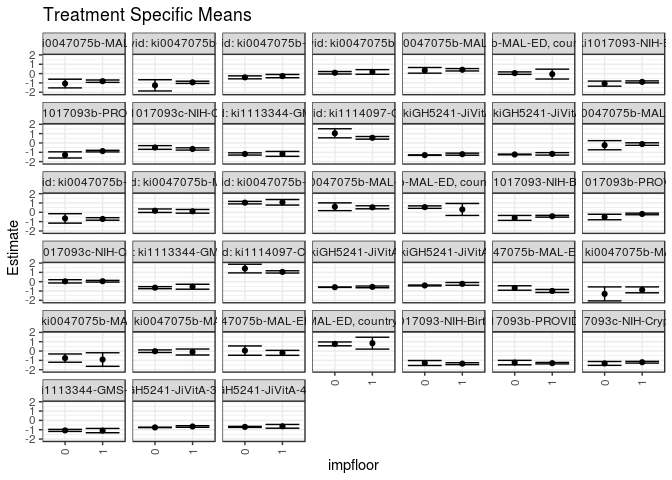

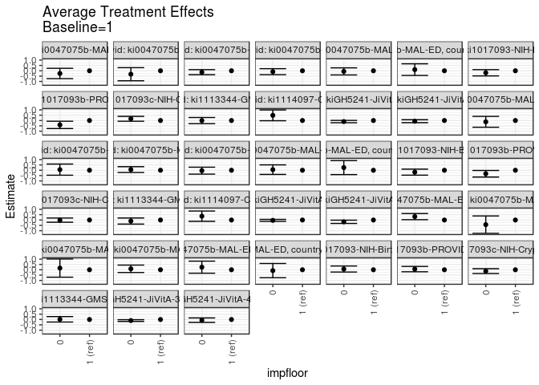

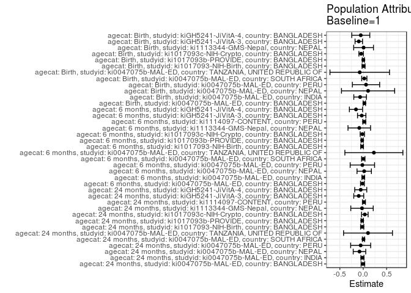

## Results Table

### Parameter: TSM

| agecat | studyid | country | intervention_level | baseline_level | estimate | ci_lower | ci_upper |
| --- | --- | --- | --- | --- | --- | --- | --- |
| Birth | ki0047075b-MAL-ED | BANGLADESH | 1 | NA | -0.9960723 | -1.1560159 | -0.8361287 |
| Birth | ki0047075b-MAL-ED | BANGLADESH | 0 | NA | -0.6771753 | -0.9163277 | -0.4380229 |
| Birth | ki0047075b-MAL-ED | INDIA | 1 | NA | -0.8772727 | -1.1935310 | -0.5610144 |
| Birth | ki0047075b-MAL-ED | INDIA | 0 | NA | -1.3116667 | -2.0623390 | -0.5609943 |
| Birth | ki0047075b-MAL-ED | NEPAL | 1 | NA | -0.9125000 | -1.6413488 | -0.1836512 |
| Birth | ki0047075b-MAL-ED | NEPAL | 0 | NA | -0.7568750 | -1.1980753 | -0.3156747 |
| Birth | ki0047075b-MAL-ED | PERU | 1 | NA | -0.1064253 | -0.4256332 | 0.2127826 |
| Birth | ki0047075b-MAL-ED | PERU | 0 | NA | -0.0179935 | -0.1557384 | 0.1197513 |
| Birth | ki0047075b-MAL-ED | SOUTH AFRICA | 1 | NA | -0.1959302 | -0.4617510 | 0.0698905 |
| Birth | ki0047075b-MAL-ED | SOUTH AFRICA | 0 | NA | 0.0466667 | -0.4532880 | 0.5466213 |
| Birth | ki0047075b-MAL-ED | TANZANIA, UNITED REPUBLIC OF | 1 | NA | 0.8440000 | 0.2094403 | 1.4785597 |
| Birth | ki0047075b-MAL-ED | TANZANIA, UNITED REPUBLIC OF | 0 | NA | 0.7655660 | 0.5608207 | 0.9703114 |
| Birth | ki1017093-NIH-Birth | BANGLADESH | 1 | NA | -1.3516243 | -1.4532286 | -1.2500200 |
| Birth | ki1017093-NIH-Birth | BANGLADESH | 0 | NA | -1.2831545 | -1.5487744 | -1.0175345 |
| Birth | ki1017093b-PROVIDE | BANGLADESH | 1 | NA | -1.3009145 | -1.3814024 | -1.2204265 |
| Birth | ki1017093b-PROVIDE | BANGLADESH | 0 | NA | -1.2387059 | -1.4768173 | -1.0005945 |
| Birth | ki1017093c-NIH-Crypto | BANGLADESH | 1 | NA | -1.1993622 | -1.2929341 | -1.1057903 |
| Birth | ki1017093c-NIH-Crypto | BANGLADESH | 0 | NA | -1.3272596 | -1.5347236 | -1.1197957 |
| Birth | ki1113344-GMS-Nepal | NEPAL | 1 | NA | -1.0935378 | -1.3237182 | -0.8633574 |
| Birth | ki1113344-GMS-Nepal | NEPAL | 0 | NA | -1.0744715 | -1.1829809 | -0.9659621 |
| Birth | kiGH5241-JiVitA-3 | BANGLADESH | 1 | NA | -0.6542094 | -0.7362808 | -0.5721379 |
| Birth | kiGH5241-JiVitA-3 | BANGLADESH | 0 | NA | -0.7530082 | -0.7717008 | -0.7343156 |
| Birth | kiGH5241-JiVitA-4 | BANGLADESH | 1 | NA | -0.6355795 | -0.8369580 | -0.4342009 |
| Birth | kiGH5241-JiVitA-4 | BANGLADESH | 0 | NA | -0.6978694 | -0.7542000 | -0.6415387 |
| 6 months | ki0047075b-MAL-ED | BANGLADESH | 1 | NA | -0.1170057 | -0.2511114 | 0.0170999 |
| 6 months | ki0047075b-MAL-ED | BANGLADESH | 0 | NA | -0.2400113 | -0.7293840 | 0.2493614 |
| 6 months | ki0047075b-MAL-ED | INDIA | 1 | NA | -0.7115403 | -0.8453770 | -0.5777037 |
| 6 months | ki0047075b-MAL-ED | INDIA | 0 | NA | -0.6528789 | -1.1587973 | -0.1469606 |
| 6 months | ki0047075b-MAL-ED | NEPAL | 1 | NA | 0.1078306 | -0.0906018 | 0.3062631 |
| 6 months | ki0047075b-MAL-ED | NEPAL | 0 | NA | 0.1712530 | -0.0157937 | 0.3582997 |
| 6 months | ki0047075b-MAL-ED | PERU | 1 | NA | 1.0734126 | 0.7773560 | 1.3694691 |
| 6 months | ki0047075b-MAL-ED | PERU | 0 | NA | 1.0361414 | 0.9005235 | 1.1717593 |
| 6 months | ki0047075b-MAL-ED | SOUTH AFRICA | 1 | NA | 0.5399822 | 0.3764649 | 0.7034995 |
| 6 months | ki0047075b-MAL-ED | SOUTH AFRICA | 0 | NA | 0.5975154 | 0.1815995 | 1.0134312 |
| 6 months | ki0047075b-MAL-ED | TANZANIA, UNITED REPUBLIC OF | 1 | NA | 0.3078449 | -0.3328520 | 0.9485418 |
| 6 months | ki0047075b-MAL-ED | TANZANIA, UNITED REPUBLIC OF | 0 | NA | 0.5567499 | 0.4216396 | 0.6918601 |
| 6 months | ki1017093-NIH-Birth | BANGLADESH | 1 | NA | -0.4204179 | -0.5172590 | -0.3235767 |
| 6 months | ki1017093-NIH-Birth | BANGLADESH | 0 | NA | -0.5976745 | -0.8617143 | -0.3336347 |
| 6 months | ki1017093b-PROVIDE | BANGLADESH | 1 | NA | -0.1763762 | -0.2628954 | -0.0898571 |
| 6 months | ki1017093b-PROVIDE | BANGLADESH | 0 | NA | -0.5040717 | -0.7990710 | -0.2090725 |
| 6 months | ki1017093c-NIH-Crypto | BANGLADESH | 1 | NA | 0.0488470 | -0.0412478 | 0.1389418 |
| 6 months | ki1017093c-NIH-Crypto | BANGLADESH | 0 | NA | 0.0367948 | -0.1385009 | 0.2120906 |
| 6 months | ki1113344-GMS-Nepal | NEPAL | 1 | NA | -0.5426602 | -0.8067645 | -0.2785560 |
| 6 months | ki1113344-GMS-Nepal | NEPAL | 0 | NA | -0.6414301 | -0.7493537 | -0.5335065 |
| 6 months | ki1114097-CONTENT | PERU | 1 | NA | 1.0469794 | 0.9261611 | 1.1677978 |
| 6 months | ki1114097-CONTENT | PERU | 0 | NA | 1.4057358 | 0.9394096 | 1.8720619 |
| 6 months | kiGH5241-JiVitA-3 | BANGLADESH | 1 | NA | -0.5596101 | -0.6501363 | -0.4690840 |
| 6 months | kiGH5241-JiVitA-3 | BANGLADESH | 0 | NA | -0.5935450 | -0.6147806 | -0.5723095 |
| 6 months | kiGH5241-JiVitA-4 | BANGLADESH | 1 | NA | -0.2348851 | -0.3801215 | -0.0896487 |
| 6 months | kiGH5241-JiVitA-4 | BANGLADESH | 0 | NA | -0.4047049 | -0.4492555 | -0.3601544 |
| 24 months | ki0047075b-MAL-ED | BANGLADESH | 1 | NA | -0.8133706 | -0.9400121 | -0.6867291 |
| 24 months | ki0047075b-MAL-ED | BANGLADESH | 0 | NA | -1.0669048 | -1.5327692 | -0.6010403 |
| 24 months | ki0047075b-MAL-ED | INDIA | 1 | NA | -0.9350909 | -1.0559668 | -0.8142150 |
| 24 months | ki0047075b-MAL-ED | INDIA | 0 | NA | -1.2588545 | -1.8602781 | -0.6574309 |
| 24 months | ki0047075b-MAL-ED | NEPAL | 1 | NA | -0.2684566 | -0.4441880 | -0.0927252 |
| 24 months | ki0047075b-MAL-ED | NEPAL | 0 | NA | -0.4016181 | -0.5600055 | -0.2432306 |
| 24 months | ki0047075b-MAL-ED | PERU | 1 | NA | 0.1754118 | -0.0738030 | 0.4246266 |
| 24 months | ki0047075b-MAL-ED | PERU | 0 | NA | 0.0898007 | -0.0426598 | 0.2222613 |
| 24 months | ki0047075b-MAL-ED | SOUTH AFRICA | 1 | NA | 0.4092370 | 0.2806764 | 0.5377976 |
| 24 months | ki0047075b-MAL-ED | SOUTH AFRICA | 0 | NA | 0.3490213 | 0.0441546 | 0.6538881 |
| 24 months | ki0047075b-MAL-ED | TANZANIA, UNITED REPUBLIC OF | 1 | NA | -0.0554642 | -0.5847605 | 0.4738321 |
| 24 months | ki0047075b-MAL-ED | TANZANIA, UNITED REPUBLIC OF | 0 | NA | 0.0521606 | -0.0781477 | 0.1824688 |
| 24 months | ki1017093-NIH-Birth | BANGLADESH | 1 | NA | -0.8887470 | -0.9938798 | -0.7836141 |
| 24 months | ki1017093-NIH-Birth | BANGLADESH | 0 | NA | -1.0765720 | -1.3498430 | -0.8033009 |
| 24 months | ki1017093b-PROVIDE | BANGLADESH | 1 | NA | -0.8711368 | -0.9569061 | -0.7853674 |
| 24 months | ki1017093b-PROVIDE | BANGLADESH | 0 | NA | -1.2819249 | -1.6127961 | -0.9510538 |
| 24 months | ki1017093c-NIH-Crypto | BANGLADESH | 1 | NA | -0.6444836 | -0.7641163 | -0.5248510 |
| 24 months | ki1017093c-NIH-Crypto | BANGLADESH | 0 | NA | -0.4850580 | -0.6838173 | -0.2862988 |
| 24 months | ki1113344-GMS-Nepal | NEPAL | 1 | NA | -1.1726174 | -1.4349846 | -0.9102503 |
| 24 months | ki1113344-GMS-Nepal | NEPAL | 0 | NA | -1.1792837 | -1.2975458 | -1.0610217 |
| 24 months | ki1114097-CONTENT | PERU | 1 | NA | 0.5518545 | 0.4100343 | 0.6936748 |
| 24 months | ki1114097-CONTENT | PERU | 0 | NA | 1.0360943 | 0.5499021 | 1.5222865 |
| 24 months | kiGH5241-JiVitA-3 | BANGLADESH | 1 | NA | -1.2028122 | -1.3136695 | -1.0919550 |
| 24 months | kiGH5241-JiVitA-3 | BANGLADESH | 0 | NA | -1.3025320 | -1.3263891 | -1.2786748 |
| 24 months | kiGH5241-JiVitA-4 | BANGLADESH | 1 | NA | -1.1697542 | -1.3029950 | -1.0365134 |
| 24 months | kiGH5241-JiVitA-4 | BANGLADESH | 0 | NA | -1.2343909 | -1.2708592 | -1.1979227 |

### Parameter: E(Y)

| agecat | studyid | country | intervention_level | baseline_level | estimate | ci_lower | ci_upper |
| --- | --- | --- | --- | --- | --- | --- | --- |
| Birth | ki0047075b-MAL-ED | BANGLADESH | NA | NA | -0.9721393 | -1.1211171 | -0.8231615 |
| Birth | ki0047075b-MAL-ED | INDIA | NA | NA | -0.9441026 | -1.2397919 | -0.6484132 |
| Birth | ki0047075b-MAL-ED | NEPAL | NA | NA | -0.8087500 | -1.1914221 | -0.4260779 |
| Birth | ki0047075b-MAL-ED | PERU | NA | NA | -0.0468095 | -0.1738806 | 0.0802616 |
| Birth | ki0047075b-MAL-ED | SOUTH AFRICA | NA | NA | -0.1729474 | -0.4186222 | 0.0727275 |
| Birth | ki0047075b-MAL-ED | TANZANIA, UNITED REPUBLIC OF | NA | NA | 0.7690991 | 0.5714748 | 0.9667234 |
| Birth | ki1017093-NIH-Birth | BANGLADESH | NA | NA | -1.3448514 | -1.4396716 | -1.2500312 |
| Birth | ki1017093b-PROVIDE | BANGLADESH | NA | NA | -1.2984586 | -1.3752758 | -1.2216415 |
| Birth | ki1017093c-NIH-Crypto | BANGLADESH | NA | NA | -1.2441513 | -1.3281130 | -1.1601897 |
| Birth | ki1113344-GMS-Nepal | NEPAL | NA | NA | -1.0860636 | -1.1830454 | -0.9890818 |
| Birth | kiGH5241-JiVitA-3 | BANGLADESH | NA | NA | -0.7496300 | -0.7674582 | -0.7318018 |
| Birth | kiGH5241-JiVitA-4 | BANGLADESH | NA | NA | -0.6882498 | -0.7406539 | -0.6358456 |
| 6 months | ki0047075b-MAL-ED | BANGLADESH | NA | NA | -0.1340556 | -0.2631866 | -0.0049245 |
| 6 months | ki0047075b-MAL-ED | INDIA | NA | NA | -0.7105603 | -0.8374801 | -0.5836404 |
| 6 months | ki0047075b-MAL-ED | NEPAL | NA | NA | 0.1286317 | -0.0051407 | 0.2624042 |
| 6 months | ki0047075b-MAL-ED | PERU | NA | NA | 1.0552716 | 0.9326038 | 1.1779394 |
| 6 months | ki0047075b-MAL-ED | SOUTH AFRICA | NA | NA | 0.5409906 | 0.3873048 | 0.6946765 |
| 6 months | ki0047075b-MAL-ED | TANZANIA, UNITED REPUBLIC OF | NA | NA | 0.5355782 | 0.4032519 | 0.6679046 |
| 6 months | ki1017093-NIH-Birth | BANGLADESH | NA | NA | -0.4447399 | -0.5354039 | -0.3540758 |
| 6 months | ki1017093b-PROVIDE | BANGLADESH | NA | NA | -0.1990907 | -0.2817968 | -0.1163845 |
| 6 months | ki1017093c-NIH-Crypto | BANGLADESH | NA | NA | 0.0297622 | -0.0491685 | 0.1086930 |
| 6 months | ki1113344-GMS-Nepal | NEPAL | NA | NA | -0.6273772 | -0.7253868 | -0.5293676 |
| 6 months | ki1114097-CONTENT | PERU | NA | NA | 1.0684318 | 0.9515274 | 1.1853362 |
| 6 months | kiGH5241-JiVitA-3 | BANGLADESH | NA | NA | -0.5921149 | -0.6117586 | -0.5724711 |
| 6 months | kiGH5241-JiVitA-4 | BANGLADESH | NA | NA | -0.3901347 | -0.4273932 | -0.3528762 |
| 24 months | ki0047075b-MAL-ED | BANGLADESH | NA | NA | -0.8201887 | -0.9423967 | -0.6979806 |
| 24 months | ki0047075b-MAL-ED | INDIA | NA | NA | -0.9522907 | -1.0676596 | -0.8369219 |
| 24 months | ki0047075b-MAL-ED | NEPAL | NA | NA | -0.3487330 | -0.4631704 | -0.2342957 |
| 24 months | ki0047075b-MAL-ED | PERU | NA | NA | 0.1204478 | 0.0005049 | 0.2403906 |
| 24 months | ki0047075b-MAL-ED | SOUTH AFRICA | NA | NA | 0.4148529 | 0.2940577 | 0.5356481 |
| 24 months | ki0047075b-MAL-ED | TANZANIA, UNITED REPUBLIC OF | NA | NA | 0.0468868 | -0.0789101 | 0.1726837 |
| 24 months | ki1017093-NIH-Birth | BANGLADESH | NA | NA | -0.9106710 | -1.0090143 | -0.8123277 |
| 24 months | ki1017093b-PROVIDE | BANGLADESH | NA | NA | -0.8928670 | -0.9755153 | -0.8102187 |
| 24 months | ki1017093c-NIH-Crypto | BANGLADESH | NA | NA | -0.6103502 | -0.7050157 | -0.5156847 |
| 24 months | ki1113344-GMS-Nepal | NEPAL | NA | NA | -1.1990840 | -1.3039914 | -1.0941766 |
| 24 months | ki1114097-CONTENT | PERU | NA | NA | 0.5668293 | 0.4302437 | 0.7034148 |
| 24 months | kiGH5241-JiVitA-3 | BANGLADESH | NA | NA | -1.2986588 | -1.3220045 | -1.2753131 |
| 24 months | kiGH5241-JiVitA-4 | BANGLADESH | NA | NA | -1.2232311 | -1.2550891 | -1.1913732 |

### Parameter: ATE

| agecat | studyid | country | intervention_level | baseline_level | estimate | ci_lower | ci_upper |
| --- | --- | --- | --- | --- | --- | --- | --- |
| Birth | ki0047075b-MAL-ED | BANGLADESH | 1 | 1 | 0.0000000 | 0.0000000 | 0.0000000 |
| Birth | ki0047075b-MAL-ED | BANGLADESH | 0 | 1 | 0.3188970 | 0.0308481 | 0.6069459 |
| Birth | ki0047075b-MAL-ED | INDIA | 1 | 1 | 0.0000000 | 0.0000000 | 0.0000000 |
| Birth | ki0047075b-MAL-ED | INDIA | 0 | 1 | -0.4343939 | -1.2489664 | 0.3801785 |
| Birth | ki0047075b-MAL-ED | NEPAL | 1 | 1 | 0.0000000 | 0.0000000 | 0.0000000 |
| Birth | ki0047075b-MAL-ED | NEPAL | 0 | 1 | 0.1556250 | -0.6963599 | 1.0076099 |
| Birth | ki0047075b-MAL-ED | PERU | 1 | 1 | 0.0000000 | 0.0000000 | 0.0000000 |
| Birth | ki0047075b-MAL-ED | PERU | 0 | 1 | 0.0884317 | -0.2595108 | 0.4363743 |
| Birth | ki0047075b-MAL-ED | SOUTH AFRICA | 1 | 1 | 0.0000000 | 0.0000000 | 0.0000000 |
| Birth | ki0047075b-MAL-ED | SOUTH AFRICA | 0 | 1 | 0.2425969 | -0.3236321 | 0.8088259 |
| Birth | ki0047075b-MAL-ED | TANZANIA, UNITED REPUBLIC OF | 1 | 1 | 0.0000000 | 0.0000000 | 0.0000000 |
| Birth | ki0047075b-MAL-ED | TANZANIA, UNITED REPUBLIC OF | 0 | 1 | -0.0784340 | -0.7452073 | 0.5883394 |
| Birth | ki1017093-NIH-Birth | BANGLADESH | 1 | 1 | 0.0000000 | 0.0000000 | 0.0000000 |
| Birth | ki1017093-NIH-Birth | BANGLADESH | 0 | 1 | 0.0684699 | -0.2156374 | 0.3525772 |
| Birth | ki1017093b-PROVIDE | BANGLADESH | 1 | 1 | 0.0000000 | 0.0000000 | 0.0000000 |
| Birth | ki1017093b-PROVIDE | BANGLADESH | 0 | 1 | 0.0622085 | -0.1885023 | 0.3129193 |
| Birth | ki1017093c-NIH-Crypto | BANGLADESH | 1 | 1 | 0.0000000 | 0.0000000 | 0.0000000 |
| Birth | ki1017093c-NIH-Crypto | BANGLADESH | 0 | 1 | -0.1278974 | -0.3548731 | 0.0990782 |
| Birth | ki1113344-GMS-Nepal | NEPAL | 1 | 1 | 0.0000000 | 0.0000000 | 0.0000000 |
| Birth | ki1113344-GMS-Nepal | NEPAL | 0 | 1 | 0.0190663 | -0.2356079 | 0.2737405 |
| Birth | kiGH5241-JiVitA-3 | BANGLADESH | 1 | 1 | 0.0000000 | 0.0000000 | 0.0000000 |
| Birth | kiGH5241-JiVitA-3 | BANGLADESH | 0 | 1 | -0.0987988 | -0.1818165 | -0.0157812 |
| Birth | kiGH5241-JiVitA-4 | BANGLADESH | 1 | 1 | 0.0000000 | 0.0000000 | 0.0000000 |
| Birth | kiGH5241-JiVitA-4 | BANGLADESH | 0 | 1 | -0.0622899 | -0.2700081 | 0.1454283 |
| 6 months | ki0047075b-MAL-ED | BANGLADESH | 1 | 1 | 0.0000000 | 0.0000000 | 0.0000000 |
| 6 months | ki0047075b-MAL-ED | BANGLADESH | 0 | 1 | -0.1230056 | -0.6313208 | 0.3853096 |
| 6 months | ki0047075b-MAL-ED | INDIA | 1 | 1 | 0.0000000 | 0.0000000 | 0.0000000 |
| 6 months | ki0047075b-MAL-ED | INDIA | 0 | 1 | 0.0586614 | -0.4648255 | 0.5821484 |
| 6 months | ki0047075b-MAL-ED | NEPAL | 1 | 1 | 0.0000000 | 0.0000000 | 0.0000000 |
| 6 months | ki0047075b-MAL-ED | NEPAL | 0 | 1 | 0.0634224 | -0.2093892 | 0.3362340 |
| 6 months | ki0047075b-MAL-ED | PERU | 1 | 1 | 0.0000000 | 0.0000000 | 0.0000000 |
| 6 months | ki0047075b-MAL-ED | PERU | 0 | 1 | -0.0372712 | -0.3642001 | 0.2896578 |
| 6 months | ki0047075b-MAL-ED | SOUTH AFRICA | 1 | 1 | 0.0000000 | 0.0000000 | 0.0000000 |
| 6 months | ki0047075b-MAL-ED | SOUTH AFRICA | 0 | 1 | 0.0575332 | -0.3909973 | 0.5060637 |
| 6 months | ki0047075b-MAL-ED | TANZANIA, UNITED REPUBLIC OF | 1 | 1 | 0.0000000 | 0.0000000 | 0.0000000 |
| 6 months | ki0047075b-MAL-ED | TANZANIA, UNITED REPUBLIC OF | 0 | 1 | 0.2489049 | -0.4060506 | 0.9038605 |
| 6 months | ki1017093-NIH-Birth | BANGLADESH | 1 | 1 | 0.0000000 | 0.0000000 | 0.0000000 |
| 6 months | ki1017093-NIH-Birth | BANGLADESH | 0 | 1 | -0.1772567 | -0.4591448 | 0.1046314 |
| 6 months | ki1017093b-PROVIDE | BANGLADESH | 1 | 1 | 0.0000000 | 0.0000000 | 0.0000000 |
| 6 months | ki1017093b-PROVIDE | BANGLADESH | 0 | 1 | -0.3276955 | -0.6351510 | -0.0202401 |
| 6 months | ki1017093c-NIH-Crypto | BANGLADESH | 1 | 1 | 0.0000000 | 0.0000000 | 0.0000000 |
| 6 months | ki1017093c-NIH-Crypto | BANGLADESH | 0 | 1 | -0.0120521 | -0.2088277 | 0.1847234 |
| 6 months | ki1113344-GMS-Nepal | NEPAL | 1 | 1 | 0.0000000 | 0.0000000 | 0.0000000 |
| 6 months | ki1113344-GMS-Nepal | NEPAL | 0 | 1 | -0.0987699 | -0.3842781 | 0.1867384 |
| 6 months | ki1114097-CONTENT | PERU | 1 | 1 | 0.0000000 | 0.0000000 | 0.0000000 |
| 6 months | ki1114097-CONTENT | PERU | 0 | 1 | 0.3587563 | -0.1232954 | 0.8408081 |
| 6 months | kiGH5241-JiVitA-3 | BANGLADESH | 1 | 1 | 0.0000000 | 0.0000000 | 0.0000000 |
| 6 months | kiGH5241-JiVitA-3 | BANGLADESH | 0 | 1 | -0.0339349 | -0.1270848 | 0.0592149 |
| 6 months | kiGH5241-JiVitA-4 | BANGLADESH | 1 | 1 | 0.0000000 | 0.0000000 | 0.0000000 |
| 6 months | kiGH5241-JiVitA-4 | BANGLADESH | 0 | 1 | -0.1698198 | -0.3226459 | -0.0169937 |
| 24 months | ki0047075b-MAL-ED | BANGLADESH | 1 | 1 | 0.0000000 | 0.0000000 | 0.0000000 |
| 24 months | ki0047075b-MAL-ED | BANGLADESH | 0 | 1 | -0.2535342 | -0.7367607 | 0.2296924 |
| 24 months | ki0047075b-MAL-ED | INDIA | 1 | 1 | 0.0000000 | 0.0000000 | 0.0000000 |
| 24 months | ki0047075b-MAL-ED | INDIA | 0 | 1 | -0.3237635 | -0.9376328 | 0.2901057 |
| 24 months | ki0047075b-MAL-ED | NEPAL | 1 | 1 | 0.0000000 | 0.0000000 | 0.0000000 |
| 24 months | ki0047075b-MAL-ED | NEPAL | 0 | 1 | -0.1331615 | -0.3697129 | 0.1033899 |
| 24 months | ki0047075b-MAL-ED | PERU | 1 | 1 | 0.0000000 | 0.0000000 | 0.0000000 |
| 24 months | ki0047075b-MAL-ED | PERU | 0 | 1 | -0.0856110 | -0.3654811 | 0.1942590 |
| 24 months | ki0047075b-MAL-ED | SOUTH AFRICA | 1 | 1 | 0.0000000 | 0.0000000 | 0.0000000 |
| 24 months | ki0047075b-MAL-ED | SOUTH AFRICA | 0 | 1 | -0.0602157 | -0.3918023 | 0.2713710 |
| 24 months | ki0047075b-MAL-ED | TANZANIA, UNITED REPUBLIC OF | 1 | 1 | 0.0000000 | 0.0000000 | 0.0000000 |
| 24 months | ki0047075b-MAL-ED | TANZANIA, UNITED REPUBLIC OF | 0 | 1 | 0.1076248 | -0.4378639 | 0.6531134 |
| 24 months | ki1017093-NIH-Birth | BANGLADESH | 1 | 1 | 0.0000000 | 0.0000000 | 0.0000000 |
| 24 months | ki1017093-NIH-Birth | BANGLADESH | 0 | 1 | -0.1878250 | -0.4805185 | 0.1048685 |
| 24 months | ki1017093b-PROVIDE | BANGLADESH | 1 | 1 | 0.0000000 | 0.0000000 | 0.0000000 |
| 24 months | ki1017093b-PROVIDE | BANGLADESH | 0 | 1 | -0.4107882 | -0.7525961 | -0.0689803 |
| 24 months | ki1017093c-NIH-Crypto | BANGLADESH | 1 | 1 | 0.0000000 | 0.0000000 | 0.0000000 |
| 24 months | ki1017093c-NIH-Crypto | BANGLADESH | 0 | 1 | 0.1594256 | -0.0699564 | 0.3888076 |
| 24 months | ki1113344-GMS-Nepal | NEPAL | 1 | 1 | 0.0000000 | 0.0000000 | 0.0000000 |
| 24 months | ki1113344-GMS-Nepal | NEPAL | 0 | 1 | -0.0066663 | -0.2947458 | 0.2814132 |
| 24 months | ki1114097-CONTENT | PERU | 1 | 1 | 0.0000000 | 0.0000000 | 0.0000000 |
| 24 months | ki1114097-CONTENT | PERU | 0 | 1 | 0.4842398 | -0.0213758 | 0.9898553 |
| 24 months | kiGH5241-JiVitA-3 | BANGLADESH | 1 | 1 | 0.0000000 | 0.0000000 | 0.0000000 |
| 24 months | kiGH5241-JiVitA-3 | BANGLADESH | 0 | 1 | -0.0997197 | -0.2106659 | 0.0112264 |
| 24 months | kiGH5241-JiVitA-4 | BANGLADESH | 1 | 1 | 0.0000000 | 0.0000000 | 0.0000000 |
| 24 months | kiGH5241-JiVitA-4 | BANGLADESH | 0 | 1 | -0.0646367 | -0.2021087 | 0.0728352 |

### Parameter: PAR

| agecat | studyid | country | intervention_level | baseline_level | estimate | ci_lower | ci_upper |
| --- | --- | --- | --- | --- | --- | --- | --- |
| Birth | ki0047075b-MAL-ED | BANGLADESH | 1 | NA | 0.0239330 | -0.0028108 | 0.0506768 |
| Birth | ki0047075b-MAL-ED | INDIA | 1 | NA | -0.0668298 | -0.2016929 | 0.0680332 |
| Birth | ki0047075b-MAL-ED | NEPAL | 1 | NA | 0.1037500 | -0.4650307 | 0.6725307 |
| Birth | ki0047075b-MAL-ED | PERU | 1 | NA | 0.0596158 | -0.2321630 | 0.3513945 |
| Birth | ki0047075b-MAL-ED | SOUTH AFRICA | 1 | NA | 0.0229829 | -0.0325492 | 0.0785150 |
| Birth | ki0047075b-MAL-ED | TANZANIA, UNITED REPUBLIC OF | 1 | NA | -0.0749009 | -0.7116467 | 0.5618449 |
| Birth | ki1017093-NIH-Birth | BANGLADESH | 1 | NA | 0.0067729 | -0.0251317 | 0.0386775 |
| Birth | ki1017093b-PROVIDE | BANGLADESH | 1 | NA | 0.0024558 | -0.0207297 | 0.0256414 |
| Birth | ki1017093c-NIH-Crypto | BANGLADESH | 1 | NA | -0.0447891 | -0.0929993 | 0.0034210 |
| Birth | ki1113344-GMS-Nepal | NEPAL | 1 | NA | 0.0074742 | -0.2041255 | 0.2190738 |
| Birth | kiGH5241-JiVitA-3 | BANGLADESH | 1 | NA | -0.0954206 | -0.1749132 | -0.0159281 |
| Birth | kiGH5241-JiVitA-4 | BANGLADESH | 1 | NA | -0.0526703 | -0.2457191 | 0.1403785 |
| 6 months | ki0047075b-MAL-ED | BANGLADESH | 1 | NA | -0.0170498 | -0.0574851 | 0.0233855 |
| 6 months | ki0047075b-MAL-ED | INDIA | 1 | NA | 0.0009801 | -0.0277862 | 0.0297464 |
| 6 months | ki0047075b-MAL-ED | NEPAL | 1 | NA | 0.0208011 | -0.1330940 | 0.1746962 |
| 6 months | ki0047075b-MAL-ED | PERU | 1 | NA | -0.0181410 | -0.2790998 | 0.2428178 |
| 6 months | ki0047075b-MAL-ED | SOUTH AFRICA | 1 | NA | 0.0010085 | -0.0351006 | 0.0371176 |
| 6 months | ki0047075b-MAL-ED | TANZANIA, UNITED REPUBLIC OF | 1 | NA | 0.2277333 | -0.3926259 | 0.8480925 |
| 6 months | ki1017093-NIH-Birth | BANGLADESH | 1 | NA | -0.0243220 | -0.0540064 | 0.0053624 |
| 6 months | ki1017093b-PROVIDE | BANGLADESH | 1 | NA | -0.0227144 | -0.0456876 | 0.0002587 |
| 6 months | ki1017093c-NIH-Crypto | BANGLADESH | 1 | NA | -0.0190847 | -0.0646940 | 0.0265245 |
| 6 months | ki1113344-GMS-Nepal | NEPAL | 1 | NA | -0.0847169 | -0.3259373 | 0.1565034 |
| 6 months | ki1114097-CONTENT | PERU | 1 | NA | 0.0214523 | -0.0103185 | 0.0532232 |
| 6 months | kiGH5241-JiVitA-3 | BANGLADESH | 1 | NA | -0.0325047 | -0.1217631 | 0.0567536 |
| 6 months | kiGH5241-JiVitA-4 | BANGLADESH | 1 | NA | -0.1552496 | -0.2959180 | -0.0145812 |
| 24 months | ki0047075b-MAL-ED | BANGLADESH | 1 | NA | -0.0068181 | -0.0454632 | 0.0318270 |
| 24 months | ki0047075b-MAL-ED | INDIA | 1 | NA | -0.0171998 | -0.0500072 | 0.0156075 |
| 24 months | ki0047075b-MAL-ED | NEPAL | 1 | NA | -0.0802764 | -0.2140358 | 0.0534829 |
| 24 months | ki0047075b-MAL-ED | PERU | 1 | NA | -0.0549640 | -0.2689982 | 0.1590702 |
| 24 months | ki0047075b-MAL-ED | SOUTH AFRICA | 1 | NA | 0.0056159 | -0.0188410 | 0.0300729 |
| 24 months | ki0047075b-MAL-ED | TANZANIA, UNITED REPUBLIC OF | 1 | NA | 0.1023510 | -0.4205658 | 0.6252678 |
| 24 months | ki1017093-NIH-Birth | BANGLADESH | 1 | NA | -0.0219240 | -0.0562007 | 0.0123527 |
| 24 months | ki1017093b-PROVIDE | BANGLADESH | 1 | NA | -0.0217303 | -0.0466582 | 0.0031976 |
| 24 months | ki1017093c-NIH-Crypto | BANGLADESH | 1 | NA | 0.0341335 | -0.0362087 | 0.1044756 |
| 24 months | ki1113344-GMS-Nepal | NEPAL | 1 | NA | -0.0264666 | -0.2663998 | 0.2134666 |
| 24 months | ki1114097-CONTENT | PERU | 1 | NA | 0.0149747 | -0.0170708 | 0.0470203 |
| 24 months | kiGH5241-JiVitA-3 | BANGLADESH | 1 | NA | -0.0958466 | -0.2024706 | 0.0107774 |
| 24 months | kiGH5241-JiVitA-4 | BANGLADESH | 1 | NA | -0.0534769 | -0.1822540 | 0.0753001 |